# Estimativa de População por Localidade

PALHOÇA - SC

Author

Rose Marie P Caldas - Instituto Mapa

Published

November 6, 2025

## 1 Introdução

Este documento apresenta uma metodologia estatística para estimar a população residente em **Localidades (Bairros)** de municípios que possuem dados geográficos limitados. O processo combina o cadastro de endereços do IBGE (georreferenciado), que informa a Localidade reportada em campo, com a malha oficial dos setores censitários, que informa a população residente. O objetivo final é distribuir a população total de cada setor censitário de forma proporcional aos endereços dentro daquele setor, obtendo uma estimativa populacional para cada Localidade identificada.

## 2 Ler arquivo de endereços do IBGE

Realiza a importação e o pré-processamento inicial do **Cadastro de Endereços para Fins Estatísticos (CEFE)** do IBGE. A etapa concentra-se em filtrar os registros para o município de interesse, selecionar as colunas essenciais (incluindo as coordenadas geográficas - LATITUDE e LONGITUDE) e converter os dados para o formato espacial (`sf`) necessário para a análise geográfica.

**Mostrar código**

```r
# 1. Leitura do arquivo (Com base no seu diagnóstico)
enderecos_raw <- read_delim(params$caminho_enderecos,
                             delim = ";",
                             locale = locale(encoding = "Latin1", decimal_mark = ",", grouping_mark = "."),
                             col_types = cols(.default = col_character()))

# 2. Seleção e Limpeza (Selecionando colunas essenciais primeiro)
enderecos_raw <- enderecos_raw %>%
  select(DSC_LOCALIDADE, LATITUDE, LONGITUDE, COD_ESPECIE, COD_MUNICIPIO,
         # Incluindo colunas adicionais que você pode precisar
         COD_UNICO_ENDERECO, starts_with("COD_"), starts_with("CD_"), everything()) %>%

  # Remove colunas desnecessárias de complementos
  select(-matches("VAL_COMP_ELEM|NOM_COMP_ELEM"),
         -DSC_ESTABELECIMENTO,
         -COD_INDICADOR_ESTAB_ENDERECO,
         -COD_INDICADOR_CONST_ENDERECO,
         -COD_INDICADOR_FINALIDADE_CONST)

# 3. Filtrar pelo Município e Espécie
enderecos_palhoca <- enderecos_raw %>%
  filter(COD_MUNICIPIO == COD_MUN, COD_ESPECIE %in% c("1", "2"))

# 4. Converte LAT/LONG e cria SF
enderecos_palhoca <- enderecos_palhoca %>%
  mutate(
    LATITUDE = as.numeric(LATITUDE),
    LONGITUDE = as.numeric(LONGITUDE)
  ) %>%
  filter(!is.na(LATITUDE), !is.na(LONGITUDE))

# Transforma em sf
enderecos_sf <- st_as_sf(enderecos_palhoca, coords = c("LONGITUDE", "LATITUDE"), crs = 4674)
```

## 3 Ler malha dos setores censitários

Nesta etapa, é feita a leitura da **Malha Digital dos Setores Censitários** (formato *Shapefile*), que contém as geometrias (polígonos) dos setores e a informação oficial da população (`v0001`) por setor. O arquivo é filtrado para reter apenas os setores pertencentes ao município em análise, servindo como a base geográfica e populacional para a estimativa.

**Mostrar código**

```r
# Lê o shapefile usando o caminho do parâmetro
setores <- st_read(params$caminho_setores, quiet = TRUE) %>%
  filter(CD_MUN == COD_MUN)
```

## 4 Identificar setor IBGE oficial para cada endereço

O objetivo desta etapa é realizar a **Junção Espacial**. Cada ponto de endereço georreferenciado é associado ao setor censitário que o contém. Esta junção atribui a cada endereço informações oficiais do setor, como o código do setor, a Situação (Urbano/Rural) e os nomes oficiais de Bairro e Distrito. Neste ponto, também garantimos a padronização de todos os nomes de localidades para **caixa alta**, evitando contagens separadas devido a diferenças de capitalização, e recuperamos as coordenadas originais (`LATITUDE`/`LONGITUDE`) necessárias para o mapa de dispersão.

**Mostrar código**

```r
# 1. Junção Espacial e Renomeação (Cria objeto temporário)
enderecos_setor_temp <- st_join(enderecos_sf, setores, join = st_within) %>%
  st_drop_geometry() %>%
  rename(SETOR_IBGE_VALIDADO = CD_SETOR,
         BAIRRO_CENSO_IBGE = NM_BAIRRO,
         DISTRITO_CENSO = NM_DIST,
         SITUACAO_SETOR = SITUACAO)

# 2. Juntar as coordenadas (LATITUDE/LONGITUDE) de volta e criar o objeto final
enderecos_setor <- enderecos_setor_temp %>%
  left_join(
    # Seleciona as coordenadas e o ID único do objeto original
    enderecos_palhoca %>% select(COD_UNICO_ENDERECO, LATITUDE, LONGITUDE),
    by = "COD_UNICO_ENDERECO"
  )

# 3. **PADRONIZAÇÃO EM CAIXA ALTA (Aplicada ao objeto final e completo)**
enderecos_setor <- enderecos_setor %>%
  mutate(
    # Colunas do setor censitário
    BAIRRO_CENSO_IBGE = toupper(BAIRRO_CENSO_IBGE),
    DISTRITO_CENSO = toupper(DISTRITO_CENSO),

    # Coluna original do endereço (DSC_LOCALIDADE)
    DSC_LOCALIDADE = toupper(DSC_LOCALIDADE)
  )

# 4. Filtra a população e a situação do setor (v0001 e SITUACAO_SETOR) para uso posterior
pop_setor <- setores %>%
  st_drop_geometry() %>%
  select(SETOR_IBGE_VALIDADO = CD_SETOR, v0001, SITUACAO_SETOR = SITUACAO)
```

### 4.1 Unificar Localidades (Priorizando Setor do IBGE)

Aqui, a coluna final de **Localidade** a ser utilizada na análise é definida. É aplicada uma regra de prioridade: se o setor censitário possui um **Bairro Codificado (IBGE)**, este nome prevalece sobre o nome reportado originalmente no cadastro de endereços (`DSC_LOCALIDADE`). Isso assegura que, sempre que houver um limite territorial oficial do IBGE para a localidade, ele seja utilizado como referência

**Mostrar código**

```r
# Cria a coluna DSC_LOCALIDADE_OFICIAL que será a base, priorizando o bairro do setor
enderecos_setor <- enderecos_setor %>%
  mutate(
    DSC_LOCALIDADE_OFICIAL = ifelse(
      !is.na(BAIRRO_CENSO_IBGE) & BAIRRO_CENSO_IBGE != "",
      BAIRRO_CENSO_IBGE,
      DSC_LOCALIDADE
    )
  )
```

## 5 Tratar nomes de localidades não oficiais

Esta seção implementa a lógica de **Tratamento de Strings**. Se ativado (parâmetro `usar_localidade_tratada: TRUE`), é utilizada a métrica de **Distância de Jaro-Winkler** para agrupar nomes de localidades que são semanticamente muito semelhantes (como erros de digitação, abreviações ou variações). O resultado final é a coluna `localidade_tratada`, que será usada para agrupar endereços que, embora grafados de maneiras diferentes, referem-se à mesma Localidade.

**Mostrar código**

```r
# Função Jaro-Winkler
agrupamento_localidades <- function(localidades, threshold = 0.2) {
  # Implementação otimizada da função de agrupamento
  ref <- localidades
  tratados <- rep(NA_character_, length(localidades))
  for (i in seq_along(localidades)) {
    if (is.na(tratados[i])) {
      # Trata NA's e vazios antes de calcular a distância (para ser mais robusto)
      if (is.na(localidades[i]) || localidades[i] == "") {
        next
      }
      similares <- stringdist::stringdistmatrix(localidades[i], ref, method = "jw") < threshold
      tratados[similares] <- localidades[i]
    }
  }
  return(tratados)
}

if (params$usar_localidade_tratada) {
  enderecos_setor <- enderecos_setor %>%
    mutate(localidade_tratada = agrupamento_localidades(DSC_LOCALIDADE_OFICIAL))
} else {
  # Se não for para tratar, a coluna 'localidade_tratada' é igual à oficial (sem tratamento de strings)
  enderecos_setor <- enderecos_setor %>%
    mutate(localidade_tratada = DSC_LOCALIDADE_OFICIAL)
}
```

## 6 Estimar população por localidade tratada

Este é o núcleo da análise. A população residente de cada Localidade é estimada utilizando o **Método de Proporcionalidade de Endereços**. A população total de um setor censitário (`v0001`) é distribuída pelas localidades que o compõem, com base na proporção de endereços de cada localidade dentro daquele setor. O resultado é um *dataframe* final com a população estimada para cada combinação de Localidade, Distrito e Situação (Urbano/Rural).

**População Estimada:**

$$População estimada = \frac{n}{N} \times P$$

Onde:

- *n* = número de endereços da localidade
- *N* = total de endereços no setor
- *P* = população total do setor (`v0001`)
- O resultado é arredondado para o número inteiro mais próximo.

**Mostrar código**

```r
# Define o nome da coluna de localidade que será usada no agrupamento final
COLUNA_LOCALIDADE_FINAL <- ifelse(params$usar_localidade_tratada, "localidade_tratada", "DSC_LOCALIDADE_OFICIAL")
NOME_FLUXO <- ifelse(params$usar_localidade_tratada, "TRATADA", "OFICIAL_PRIORIDADE_IBGE")

# 5.1. Preparação de Dados Comuns
total_enderecos_por_setor <- enderecos_setor %>%
  count(SETOR_IBGE_VALIDADO, name = "total_enderecos")

# 5.2. Estimar População

# Código da Seção 5 (Com a correção de NOME_LOCALIDADE_FINAL)
pop_localidade_final <- enderecos_setor %>%
  mutate(NOME_LOCALIDADE_FINAL = .data[[COLUNA_LOCALIDADE_FINAL]]) %>%
  # Aqui SITUACAO_SETOR existe, e o resultado do count tem:
  # SETOR_IBGE_VALIDADO, NOME_LOCALIDADE_FINAL, DISTRITO_CENSO, SITUACAO_SETOR, n_enderecos
  count(SETOR_IBGE_VALIDADO, NOME_LOCALIDADE_FINAL, DISTRITO_CENSO, SITUACAO_SETOR, name = "n_enderecos") %>%

  # O primeiro join não afeta a SITUACAO_SETOR
  left_join(total_enderecos_por_setor, by = "SETOR_IBGE_VALIDADO") %>%

# O segundo join: *** CORREÇÃO AQUI ***
  # Inclua SITUACAO_SETOR na cláusula 'by' para evitar o conflito de nomes e forçar o matching
  left_join(pop_setor, by = c("SETOR_IBGE_VALIDADO", "SITUACAO_SETOR")) %>%
  # ... (resto do pipeline)
  mutate(pop_estimada = round((n_enderecos / total_enderecos) * as.numeric(v0001), 0)) %>%

  # Sumarização Final
  group_by(NOME_LOCALIDADE_FINAL, DISTRITO_CENSO, SITUACAO_SETOR) %>%
  summarise(pop_total_estimada = sum(pop_estimada, na.rm = TRUE), .groups = 'drop') %>%
  arrange(desc(pop_total_estimada))
```

## 7 População Estimada por Localidade (Tabela HTML)

**Mostrar código**

```r
library(knitr)
# 1. Formata a coluna populacional para melhor apresentação visual (com separador de milhar)
pop_localidade_final_formatted <- pop_localidade_final %>%
  # Usa scales::comma para formatar os números de população com pontos e vírgulas (padrão BR)
  mutate(
    População_Estimada = scales::comma(pop_total_estimada, big.mark = ".", decimal.mark = ",")
  ) %>%
  # Seleciona e renomeia as colunas finais para o cabeçalho da tabela
  select(
    Localidade = NOME_LOCALIDADE_FINAL,
    Distrito = DISTRITO_CENSO,
    Situação = SITUACAO_SETOR,
    População_Estimada
  )

# 2. Usa knitr::kbl para criar uma tabela HTML apresentável
kable(
  pop_localidade_final_formatted,
  caption = "População Total Estimada por Localidade",
  align = c('l', 'l', 'l', 'r')
) %>%
  kable_styling(
    bootstrap_options = c("striped", "hover", "condensed"),
    full_width = FALSE,
    position = "center"
  ) %>%
  collapse_rows(columns = 1, valign = "top")
```

População Total Estimada por Localidade

| Localidade | Distrito | Situação | População_Estimada |
| --- | --- | --- | --- |
| ARIRIU | PALHOÇA | Urbana | 19.535 |
| BELA VISTA | PALHOÇA | Urbana | 17.951 |
| PONTE DO IMARUIM | PALHOÇA | Urbana | 17.399 |
| SAO SEBASTIAO | PALHOÇA | Urbana | 15.975 |
| BARRA DO ARIRIU | PALHOÇA | Urbana | 13.771 |
| CAMINHO NOVO | PALHOÇA | Urbana | 11.233 |
| PEDRA BRANCA | PALHOÇA | Urbana | 9.675 |
| ALTO ARIRIU | PALHOÇA | Urbana | 9.493 |
| PASSA VINTE | PALHOÇA | Urbana | 9.214 |
| GUARDA DO CUBATAO | PALHOÇA | Urbana | 8.444 |
| CENTRO | PALHOÇA | Urbana | 7.640 |
| PRAIA DE FORA | ENSEADA DE BRITO | Urbana | 6.665 |
| NOVA PALHOCA | PALHOÇA | Urbana | 6.645 |
| FREI DAMIAO | PALHOÇA | Urbana | 6.361 |
| BREJARU | PALHOÇA | Urbana | 5.631 |
| RIO GRANDE | PALHOÇA | Urbana | 5.225 |
| PACHECO | PALHOÇA | Urbana | 5.059 |
| TERRA NOVA | PALHOÇA | Urbana | 5.020 |
| MADRI | PALHOÇA | Urbana | 4.964 |
| VILA NOVA | PALHOÇA | Urbana | 3.825 |
| JARDIM ELDORADO | PALHOÇA | Urbana | 2.905 |
| PASSAGEM DO MACIAMBU | ENSEADA DE BRITO | Urbana | 2.691 |
| ENSEADA DE BRITO | ENSEADA DE BRITO | Urbana | 2.634 |
| LOTEAMENTO PAGANI | PALHOÇA | Urbana | 2.622 |
| JARDIM AQUARIUS | PALHOÇA | Urbana | 2.516 |
| PRAIA DO MEIO | ENSEADA DE BRITO | Urbana | 2.218 |
| PORTAL DA BARRA | PALHOÇA | Urbana | 2.164 |
| PINHEIRA | ENSEADA DE BRITO | Urbana | 2.073 |
| LARANJEIRAS | PALHOÇA | Urbana | 1.874 |
| PAGANI | PALHOÇA | Urbana | 1.695 |
| PONTAL | ENSEADA DE BRITO | Urbana | 1.376 |
| GUARDA DO CUBATAO | ENSEADA DE BRITO | Urbana | 909 |
| FURADINHO | ENSEADA DE BRITO | Urbana | 907 |
| ALBARDAO | ENSEADA DE BRITO | Rural | 880 |
| GUARDA DO EMBAU | ENSEADA DE BRITO | Urbana | 706 |
| PRAIA DO SONHO | ENSEADA DE BRITO | Urbana | 704 |
| PRAIA DA PINHEIRA | ENSEADA DE BRITO | Urbana | 450 |
| PONTA DO PAPAGAIO | ENSEADA DE BRITO | Urbana | 403 |
| SAO SEBASTIAO | PALHOÇA | Rural | 354 |
| JARDIM DAS PALMEIRAS | PALHOÇA | Urbana | 298 |
| MACIAMBU | ENSEADA DE BRITO | Rural | 241 |
| TRES BARRAS | ENSEADA DE BRITO | Rural | 238 |
| SERTAO DO CAMPO | ENSEADA DE BRITO | Rural | 231 |
| ALBARDAO | ENSEADA DE BRITO | Urbana | 217 |
| BARRA VILA NOVA | PALHOÇA | Urbana | 165 |
| JARDIM COQUEIROS | PALHOÇA | Urbana | 146 |
| MACIAMBU PEQUENO | ENSEADA DE BRITO | Rural | 124 |
| ALDEIA INDIGENA ITATY | ENSEADA DE BRITO | Rural | 123 |
| ENSEADA DE BRITO | ENSEADA DE BRITO | Rural | 120 |
| AUTO ARIRIU | PALHOÇA | Urbana | 112 |
| PAGARA | PALHOÇA | Rural | 107 |
| FORMIGA | PALHOÇA | Urbana | 80 |
| CAMBIRELA | ENSEADA DE BRITO | Urbana | 64 |
| PASSAGEM DO MACIAMBU | ENSEADA DE BRITO | Rural | 57 |
| ALDEIA INDIGENA PIRA RUPA MASSIAMBU | ENSEADA DE BRITO | Urbana | 45 |
| BAIXADA DO MACIAMBU | ENSEADA DE BRITO | Rural | 43 |
| GUARDA DO CUBATAO | PALHOÇA | Rural | 42 |
| JARDIM MEIRELES | PALHOÇA | Urbana | 36 |
| COLONIA DE PESCADORES ARACATUBA | ENSEADA DE BRITO | Urbana | 34 |
| ENSEADA | ENSEADA DE BRITO | Urbana | 33 |
| ALDEIA INDIGENA MORRO DOS CAVALOS | ENSEADA DE BRITO | Rural | 32 |
| COMUNIDADE RIBEIRINHA MACIAMBU | ENSEADA DE BRITO | Urbana | 27 |
| ALTO ARIRIU | PALHOÇA | Rural | 22 |
| PRAIA DO MEIO | ENSEADA DE BRITO | Rural | 19 |
| COMUNIDADE RIBEIRINHA MONTEIRO TALLES | ENSEADA DE BRITO | Rural | 13 |
| MACIAMBU | ENSEADA DE BRITO | Urbana | 8 |
| PAGARA | PALHOÇA | Urbana | 6 |
| TRES BARRAS | ENSEADA DE BRITO | Urbana | 6 |
| ARIRIU | PALHOÇA | Rural | 5 |
| BARRA DO ARIRIU | PALHOÇA | Rural | 5 |
| PEDRA BRANCA | PALHOÇA | Rural | 5 |
| GUARDA DO EMBAU | ENSEADA DE BRITO | Rural | 3 |
| CENTRO | PALHOÇA | Rural | 2 |
| MORADIA | PALHOÇA | Rural | 2 |
| BREJARU | NA | NA | 0 |
| ENSEADA | ENSEADA DE BRITO | Rural | 0 |
| MORRO DA PINHEIRA | ENSEADA DE BRITO | Rural | 0 |
| PINHEIRA | ENSEADA DE BRITO | Rural | 0 |
|  | NA | NA | 0 |

## 8 Exportar resultados

Nesta etapa, o resultado final da estimativa populacional (a tabela `pop_localidade_final`) é exportado para um arquivo **Excel (`.xlsx`)**, que pode ser utilizado para relatórios e análises externas.

**Mostrar código**

```r
# Concatena o caminho da pasta com o nome do arquivo
nome_saida <- file.path(PASTA_SAIDA, paste0("populacao_por_localidade_", NOME_FLUXO, "_", COD_MUN, ".xlsx"))
write.xlsx(pop_localidade_final, nome_saida)

cat(paste0("Arquivo exportado com sucesso: ", nome_saida))
```

```
Arquivo exportado com sucesso: resultados/populacao_por_localidade_OFICIAL_PRIORIDADE_IBGE_4211900.xlsx
```

## 9 7. Gerar malha de localidades

Esta seção é responsável pela preparação geográfica para a visualização. Ela dissolve as fronteiras dos setores censitários que pertencem à mesma Localidade, criando polígonos maiores que representam os **Limites das Localidades** conforme a distribuição dos endereços e a regra de prioridade estabelecida. O resultado (`malha_localidades_final`) é exportado como um **Shapefile** e utilizado para o mapa de fronteiras.

**Mostrar código**

```r
# 7.1. Gerar Malha Geográfica da Localidade Escolhida
mapa_setor_localidade_data <- enderecos_setor %>%
  # CORREÇÃO: Usa all_of() para seleção dinâmica no select()
  select(SETOR_IBGE_VALIDADO, all_of(COLUNA_LOCALIDADE_FINAL), DISTRITO_CENSO) %>%
  distinct() %>%
  # CORREÇÃO: Usa all_of() para seleção dinâmica no rename()
  rename(NOME_LOCALIDADE_FINAL = all_of(COLUNA_LOCALIDADE_FINAL)) %>%
  # Junta a população, mas precisa primeiro somar a população total por Localidade/Distrito
  left_join(
    pop_localidade_final %>%
      group_by(NOME_LOCALIDADE_FINAL, DISTRITO_CENSO) %>%
      # Agrega a população total (Urbano + Rural) para o mapa
      summarise(pop_total_estimada = sum(pop_total_estimada, na.rm = TRUE), .groups = 'drop'),
    by = c("NOME_LOCALIDADE_FINAL", "DISTRITO_CENSO")
  )

# 7.2. Juntar os Dados ao Objeto de Geometria 'setores'
setores_com_dados <- setores %>%
  rename(SETOR_IBGE_VALIDADO = CD_SETOR) %>%
  left_join(mapa_setor_localidade_data, by = "SETOR_IBGE_VALIDADO") %>%
  filter(!is.na(NOME_LOCALIDADE_FINAL))

# 7.3. Dissolver/Agregar as Geometrias dos Setores (CORREÇÃO DO ERRO 'geometry' NÃO ENCONTRADO)
malha_localidades_final <- setores_com_dados %>%
  group_by(NOME_LOCALIDADE_FINAL, DISTRITO_CENSO) %>%
  summarise(
    pop_total_estimada = sum(pop_total_estimada, na.rm = TRUE),
    geometry = st_union(geometry),
    .groups = 'drop'
  )

# =========================================================
# *** EXPORTAR SHAPEFILE DOS LIMITES ***
# =========================================================
# Concatena o caminho da pasta com o nome do arquivo
nome_shp_saida <- file.path(PASTA_SAIDA, paste0("limites_localidades_", NOME_FLUXO, "_", COD_MUN, ".shp"))
st_write(malha_localidades_final, nome_shp_saida, delete_layer = TRUE, quiet = TRUE)
cat(paste0("Shapefile de limites exportado com sucesso: ", nome_shp_saida, "\n"))
```

```
Shapefile de limites exportado com sucesso: resultados/limites_localidades_OFICIAL_PRIORIDADE_IBGE_4211900.shp
```

**Mostrar código**

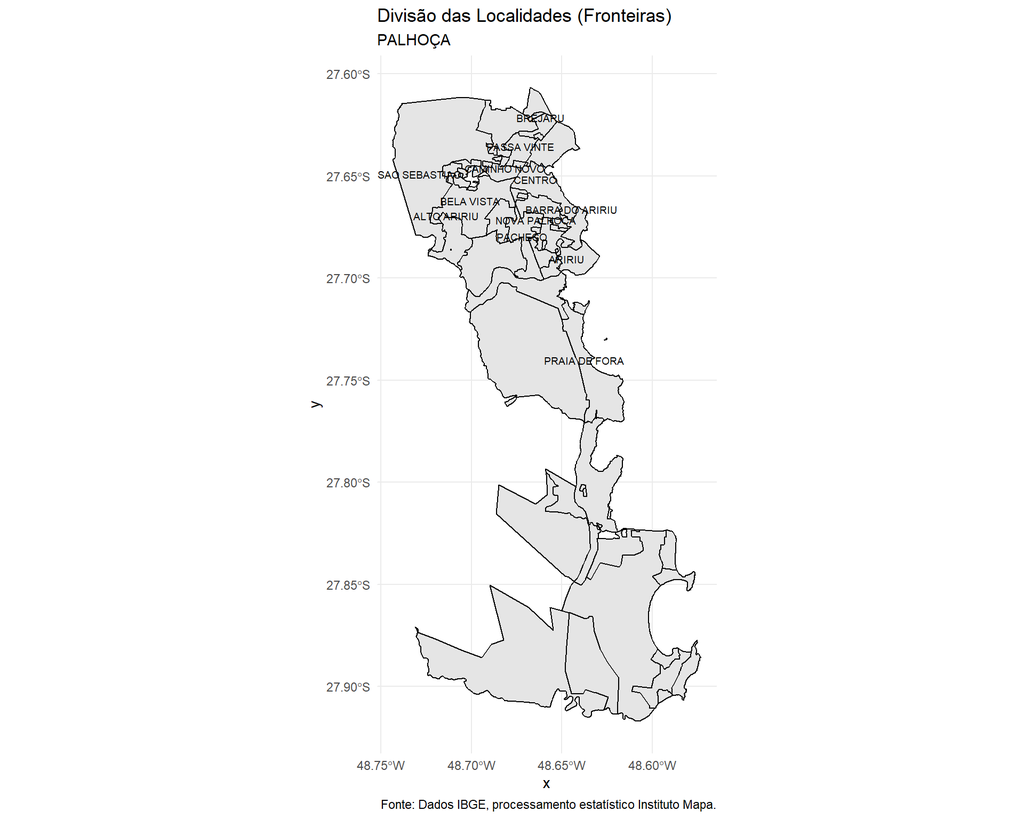

```r
# =========================================================

# 7.4. Plotar o Mapa (COM FOCO APENAS NAS DIVISÕES DE LOCALIDADE)

malha_filtrada <- malha_localidades_final %>%
  filter(pop_total_estimada > 0)

# 1. Subconjunto para rótulos (as maiores localidades)
labels_subset <- subset(malha_filtrada, pop_total_estimada > quantile(pop_total_estimada, 0.75))

# 2. Projeta o subconjunto de rótulos para um CRS Planar (UTM 22S, EPSG: 31982)
#    Garante o cálculo correto do centroide para os rótulos.
labels_projected <- labels_subset %>% st_transform(31982)

ggplot(data = malha_filtrada) +
  # *** CORREÇÃO AQUI: Removemos o 'fill' de aes() e definimos uma cor sólida ***
  geom_sf(fill = "gray90", color = "black", linewidth = 0.5) +

  # *** REMOÇÃO: A escala de preenchimento (scale_fill_viridis_c) foi removida ***

  labs(
    title = paste("Divisão das Localidades (Fronteiras)"),
    subtitle = NOME_MUN,
    caption = "Fonte: Dados IBGE, processamento estatístico Instituto Mapa."
  ) +
  theme_minimal() +
  # 3. Adiciona um rótulo básico nas maiores localidades, usando os dados PROJETADOS
  geom_sf_text(
    data = labels_projected,
    aes(label = NOME_LOCALIDADE_FINAL),
    size = 2.5,
    check_overlap = TRUE
  )
```

## 10 Mapa de Dispersão dos Endereços por Localidade

Este capítulo visualiza a **Distribuição Espacial Bruta** de todos os endereços, agrupados por sua Localidade final. Cada ponto de endereço é plotado e colorido, e um **Centroide** é calculado para cada agrupamento, onde o nome da Localidade é rotulado. Este mapa ajuda a verificar a extensão geográfica de cada Localidade, independentemente das fronteiras formais do setor censitário

**Mostrar código**

```r
# --- Diagnóstico de Leitura ---
# Altere o caminho se necessário. Usamos o caminho parametrizado:
caminho <- params$caminho_enderecos

# Tenta ler com a configuração atual
teste_leitura <- read_delim(caminho, delim = ";", n_max = 5,
                            locale = locale(encoding = "Latin1", decimal_mark = ",", grouping_mark = "."),
                            col_types = cols(.default = col_character()))
```

**Mostrar código**

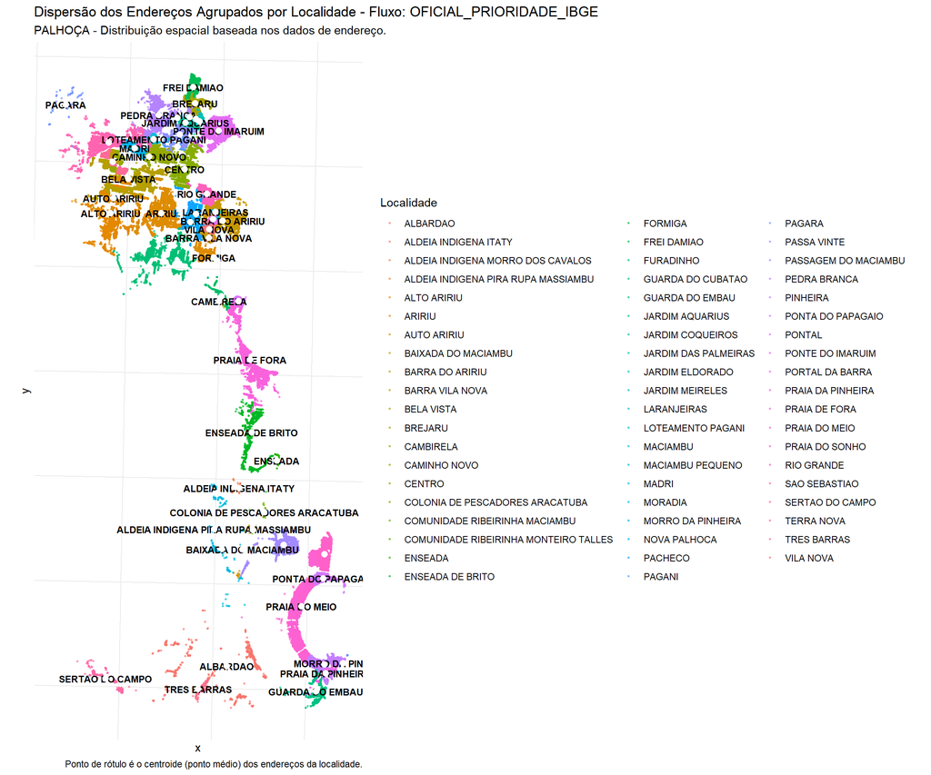

```r
# 1. Preparar o objeto SF dos endereços usando a LOCALIDADE FINAL escolhida
#    Usamos a coluna LATITUDE/LONGITUDE original do enderecos_setor
enderecos_sf_plot <- enderecos_setor %>%
  # Seleciona apenas as colunas necessárias para o plot de pontos
  select(LATITUDE, LONGITUDE, NOME_LOCALIDADE_FINAL = all_of(COLUNA_LOCALIDADE_FINAL)) %>%
  # Converte o dataframe para um objeto SF para calcular o centroide
  st_as_sf(coords = c("LONGITUDE", "LATITUDE"), crs = 4674) %>%
  # Remove NAs para garantir um plot limpo
  filter(!is.na(NOME_LOCALIDADE_FINAL))

# 2. Calcular o Centroide (Ponto Central) para cada Localidade
centroides_localidades <- enderecos_sf_plot %>%
  # Agrupa por Localidade Final
  group_by(NOME_LOCALIDADE_FINAL) %>%
  # Sumariza, calculando o centroide de todos os pontos daquele grupo
  summarise(geometry = st_centroid(st_union(geometry)), .groups = 'drop') %>%
  # Transforma para um CRS planar (UTM) para rótulos precisos
  st_transform(31982)

# 3. Preparar os dados de endereço para plotagem (opcionalmente projetados)
#    Geralmente, plota-se no CRS geográfico (4674) para fundo de mapa,
#    mas projetar os pontos pode ser útil para densidade.
enderecos_sf_plot_proj <- enderecos_sf_plot %>% st_transform(31982)

# 4. Criação do Mapa
ggplot() +
  # 4.1. Plotar todos os endereços como pontos, coloridos por Localidade
  geom_sf(data = enderecos_sf_plot_proj,
          aes(color = NOME_LOCALIDADE_FINAL),
          size = 0.5,
          alpha = 0.6) +

  # 4.2. Adicionar os rótulos no centroide
  geom_sf_text(data = centroides_localidades,
               aes(label = NOME_LOCALIDADE_FINAL),
               color = "black",
               size = 3,
               fontface = "bold",
               check_overlap = TRUE) +

  # 4.3. Adicionar pontos centrais brancos (para destacar o centroide)
  geom_sf(data = centroides_localidades,
          size = 2.5,
          color = "white") +

  scale_color_discrete(name = "Localidade") + # Legenda de cores

  labs(
    title = paste("Dispersão dos Endereços Agrupados por Localidade - Fluxo:", NOME_FLUXO),
    subtitle = paste(NOME_MUN, "- Distribuição espacial baseada nos dados de endereço."),
    caption = "Ponto de rótulo é o centroide (ponto médio) dos endereços da localidade."
  ) +
  theme_minimal() +
  # Remover eixos de coordenadas
  theme(axis.text = element_blank(),
        axis.ticks = element_blank())
```

## 11 Resumo final dos indicadores

Este capítulo apresenta um **painel executivo** comparando a população total oficial do Censo (base) com a população total estimada pelo modelo. O objetivo é fornecer uma visão geral da qualidade da estimativa, calculando a **porcentagem de população não estimada (perda)** e a distribuição Urbana/Rural da população base do Censo.

**Mostrar código**

```r
# Garante que v0001 é numérico no pop_setor
pop_setor_clean <- pop_setor %>%
  mutate(v0001_num = as.numeric(v0001))

# 1. População Total dos Setores Censitários (População Censo)
pop_total_censo <- sum(pop_setor_clean$v0001_num, na.rm = TRUE)

# 2. População Urbana e Rural dos Setores Censitários
pop_urbana_censo <- pop_setor_clean %>%
  filter(SITUACAO_SETOR == "Urbana") %>%
  summarise(total = sum(v0001_num, na.rm = TRUE)) %>%
  pull(total)

pop_rural_censo <- pop_setor_clean %>%
  filter(SITUACAO_SETOR == "Rural") %>%
  summarise(total = sum(v0001_num, na.rm = TRUE)) %>%
  pull(total)

# 3. População Total Estimada (População Endereços)
pop_total_estimada <- sum(pop_localidade_final$pop_total_estimada, na.rm = TRUE)

# 4. Cálculos de Porcentagem
perc_urbana <- round((pop_urbana_censo / pop_total_censo) * 100, 2)
perc_rural <- round((pop_rural_censo / pop_total_censo) * 100, 2)

# 5. Porcentagem de População Não Estimada
pop_nao_estimada <- pop_total_censo - pop_total_estimada
perc_nao_estimada <- round((pop_nao_estimada / pop_total_censo) * 100, 2)

# --- 1. Cria o dataframe de Totais Populacionais ---
# Usa scales::comma para formatar os números para visualização
df_totais <- data.frame(
  Métrica = c(
    "População Total (Censo IBGE)",
    "População Total Estimada (Modelo)",
    "População Não Estimada (Perda)"
  ),
  Valor = c(
    scales::comma(pop_total_censo, big.mark = ".", decimal.mark = ","),
    scales::comma(pop_total_estimada, big.mark = ".", decimal.mark = ","),
    scales::comma(pop_nao_estimada, big.mark = ".", decimal.mark = ",")
  ),
  stringsAsFactors = FALSE
)

# --- 2. Cria o dataframe de Porcentagens ---
df_percentuais <- data.frame(
  Métrica = c(
    "Percentual Não Estimado (Perda)",
    "População Urbana (Censo Base)",
    "População Rural (Censo Base)"
  ),
  Valor = c(
    paste0(perc_nao_estimada, " %"),
    paste0(perc_urbana, " %"),
    paste0(perc_rural, " %")
  ),
  stringsAsFactors = FALSE
)

# --- 3. Renderiza os Resultados em HTML ---

#cat("### Resultados do Levantamento de População por Localidade\n\n")
#cat(paste("Município:", NOME_MUN, "\n\n"))

# 3.1. Renderiza a Tabela de Totais
#cat("#### Totais Populacionais\n")
knitr::kable(
  df_totais,
  caption = "Comparativo População Censo vs. Estimada",
  align = c('l', 'r') # Alinha texto à esquerda, números à direita
)
```

Comparativo População Censo vs. Estimada

| Métrica | Valor |
| --- | --- |
| População Total (Censo IBGE) | 222.598 |
| População Total Estimada (Modelo) | 222.517 |
| População Não Estimada (Perda) | 81 |

**Mostrar código**

```r
# 3.2. Renderiza a Tabela de Porcentagens
#cat("\n#### Detalhamento Percentual\n")
knitr::kable(
  df_percentuais,
  caption = "Percentuais de Cobertura e Distribuição Censo",
  align = c('l', 'r')
)
```

Percentuais de Cobertura e Distribuição Censo

| Métrica | Valor |
| --- | --- |
| Percentual Não Estimado (Perda) | 0.04 % |
| População Urbana (Censo Base) | 98.79 % |
| População Rural (Censo Base) | 1.21 % |